# RUVprps normalization on TCGA BRCA RNA-seq data - data preprocessing

Momeneh Foroutan and Ramyar Molania

Biomedicine Discovery Institute and the Department of Biochemistry and Molecular Biology, Monash University, VIC, Australia.  
Department of Medical Oncology, Dana-Farber Cancer Institute, Boston, MA, USA  
Harvard Medical School, Boston, MA, USA.

2026-06-02

#### Package

RUVprps 0.99.0

# 1 Introduction

We show the application of the **RUVprps** package to the TCGA Breast Cancer Invasive Carcinoma (BRCA) RNA-seq dataset. The goal is to remove the variation associated with tumor purity, alongside other sources of unwanted variation (UV) such as library size and batch effects, using the RUV-III with Pseudo-Replicates of Pseudo-Samples (PRPS) framework. In this, we show how to preprocess the TCGA BRCA RNA-seq data for RUV-III with PRPS normalization.

## 1.1 Overview of the pipeline

The RUVprps procedure consists of four stages, each with one or more steps:

| Stage | Purpose |
| --- | --- |
| 1 | Data preparation and processing |
| 2 | Identification of biological variation and UV |
| 3 | Variation assessment |
| 4 | RUV-III normalization and performance evaluation |

## 1.2 Required packages

The R packages below are required for the analysis in this vignette.

```r
library(SummarizedExperiment)
library(ComplexHeatmap)
library(TCGAbiolinks)
library(gridExtra)
library(ggplot2)
library(RUVprps)
library(genefu)
library(ggpubr)
library(dplyr)
library(grid)
library(qs)
```

# 2 Data preparation and processing

## 2.1 Step 1: downloading the data

The most recent TCGA BRCA RNA-seq data are downloaded from the GDC data portal using the **TCGAbiolinks** R package. The files are saved to the current working directory.After preparation, normal tissue samples are excluded so that only primary tumor samples are retained for all downstream analyses.

```r
tcga.brca.rnaseq.data <- GDCquery(
    project       = 'TCGA-BRCA',
    data.category = 'Transcriptome Profiling',
    data.type     = 'Gene Expression Quantification')
GDCdownload(tcga.brca.rnaseq.data)
brca.se.obj <- GDCprepare(query = tcga.brca.rnaseq.data)
# Retain only primary tumor tissue samples.
brca.se.obj <- brca.se.obj[, brca.se.obj$tissue_type == 'Tumor']
# we save this object for reproduciblity
# qs::qsave(
#     x = brca.se.obj,
#     file = 'TCGA_BrcaRnaSeq_StarCounts38_TCGAbiolinks.021424.qs'
#     )
```

| Data (assay) | Description |
| --- | --- |
| `unstranded` | Raw counts, unstranded (used as RawCount) |
| `stranded_first` | Raw counts, first-strand |
| `stranded_second` | Raw counts, second-strand |
| `tpm_unstrand` | TPM normalized |
| `fpkm_unstrand` | FPKM normalized |
| `fpkm_uq_unstrand` | FPKM normalized followed by upper-quartile normalization |

```r
brca.se.obj <- qread(file = 'TCGA_BrcaRnaSeq_StarCounts38_TCGAbiolinks.021424.qs')
brca.se.obj <- brca.se.obj[ , brca.se.obj$tissue_type == 'Tumor']
# removeAssays() drops the two stranded count assays that are redundant with
# the unstranded assay for this analysis.
brca.se.obj <- removeAssays(
    se.obj           = brca.se.obj,
    assays.to.remove = c('stranded_first', 'stranded_second'))
# renameAssays() replaces the original TCGA assay names with shorter or other names,
brca.se.obj <- renameAssays(
    se.obj    = brca.se.obj,
    new.names = c('RawCount', 'TPM', 'FPKM', 'FPKM.UQ'))
```

## 2.2 Step 2: Selecting gene types of interest (optional)

The `gene_type` column in the gene annotation (`rowData`) classifies each Ensembl transcript into a biotype category (e.g. `protein_coding`, `lncRNA`, `pseudogene`, …). For this analysis only **protein-coding** genes with **unique HGNC symbols** are retained. Row names of the `SummarizedExperiment` are updated from Ensembl IDs to HGNC gene symbols to simplify downstream interpretation and to enable matching against external gene lists (e.g. housekeeping genes, PAM50 signature genes).

```r
# tidyGenes() performs three operations in one call:
#   1. Retains only rows annotated as 'protein_coding' in gene_type.
#   2. Removes duplicate HGNC symbols (keeping one representative transcript
#      per gene symbol) so that row names are unique.
#   3. Replaces Ensembl IDs with HGNC symbols as row names
#      (change.row.names = TRUE, new.row.names = 'gene_name').
brca.se.obj <- tidyGenes(
    se.obj                = brca.se.obj,
    keep.gene.type        = 'protein_coding',
    gene.type.col.name    = 'gene_type',
    remove.duplicates.ids = TRUE,
    ids.col.name          = 'gene_name',
    change.row.names      = TRUE,
    new.row.names         = 'gene_name')
rowData(brca.se.obj)
```

After filtering, **19,934 Ensembl transcripts** are retained.

## 2.3 Step 3: Adding batch details

TCGA RNA-seq samples were collected from multiple Tissue Source Sites (TSS), shipped to different genomics profiling centers, and sequenced on 96-well sequencing plates across several years. These are well-documented sources of batch effects that affect downstream analyses.

`addTcgaBatchInfo()` annotates each sample with all available TCGA batch metadata, retrieved from the supplementary file `41587_2022_1440_MOESM3_ESM.xlsx` from Molania et al. ( Nature Biotechnology2023). The TCGA sample barcode encodes TSS, plate, and centre information (see the [GDC barcode documentation](https://docs.gdc.cancer.gov/Encyclopedia/pages/TCGA_Barcode/) for full details).

`orderSeObj()` then sorts samples chronologically by the specified batch variables so that time-related batch patterns become contiguous, a requirement for the RLE-based batch detection used in Stage 2.

```r
# addTcgaBatchInfo() parses the TCGA sample barcodes and the external
# batch annotation file to append Year, Month, Day, Plate, TSS, and
# Center information to colData as new columns.
brca.se.obj       <- addTcgaBatchInfo(se.obj = brca.se.obj)
brca.se.obj$Years <- as.factor(x = brca.se.obj$Years)

# orderSeObj() sorts samples first by sequencing year, then by plate ID.
brca.se.obj <- orderSeObj(
    se.obj           = brca.se.obj,
    factors.to.order = c('Years', 'Plates'))
```

The TCGA BRCA RNA-seq dataset now comprises **1,083 cancer tissue samples** collected from **40 Tissue Source Sites (TSS)**, distributed across **37 sequencing plates**, and profiled over **5 years (2010–2014)**. Samples from 2010–2011 were sequenced using one flow cell chemistry; samples from 2012–2014 used a different chemistry. This chemistry change is a major source of UV in this dataset.

## 2.4 Step 4: Preparing the SummarizedExperiment object

`prepareSeObj()` performs several preprocessing tasks in a single call, producing a fully annotated object ready for normalization:

- **Lowly expressed gene removal**: genes failing the CPM expression cutoff in a minimum number of samples are dropped.
- **Library size calculation**: per-sample total count sums are computed from the `RawCount` assay and stored in `colData`.
- **Tumor purity estimation**: two methods are applied, the ESTIMATE and singscore methods, both computed from the `FPKM.UQ` assay. The singscore values are rescaled to the ESTIMATE [0, 1].
- **Housekeeping and immune/stromal gene integration**: curated gene lists are attached to `rowData` for use as negative control gene (NCG) candidates and biological reference sets.

The `column.name = 'gene_name'` argument tells the function which `rowData` column contains the gene identifiers; it uses this to create a new `hgnc_symbol` column for gene-list matching.

```r
brca.se.obj <- prepareSeObj(
    data                          = brca.se.obj,
    raw.count.assay.name          = 'RawCount',
    remove.lowly.expressed.genes  = TRUE,
    assay.name.to.estimate.purity = 'FPKM.UQ',
    estimate.tumor.purity         = 'both',
    scale.singscore.values        = TRUE,
    calculate.library.size        = TRUE,
    add.immun.stroma.genes        = TRUE,
    add.gene.details              = TRUE,
    add.housekeeping.genes        = TRUE,
    column.name                   = 'gene_name',
    gene.group                    = 'hgnc_symbol',
    verbose                       = FALSE)
# qs::qsave(
#     x    = brca.se.obj,
#     file = 'TCGA_BrcaRnaSeq_StarCounts38_TCGAbiolinks.021424_RuvSeObj.qs')
```

**15,304 of 19,934** Ensembl transcripts pass the expression filter (CPM $\geq$ 0.18 in at least 598 samples — the default threshold of the function). Tumor purity estimated by ESTIMATE and singscore are highly correlated; the ESTIMATE values are used for all downstream analysis.

## 2.5 Step 5: Visualising the study outline

`plotStudyOutline()` produces a summary figure showing the distribution of all specified variables across samples and a pairwise correlation matrix between them. Before plotting, variable names are standardized with `renameVariables()`.

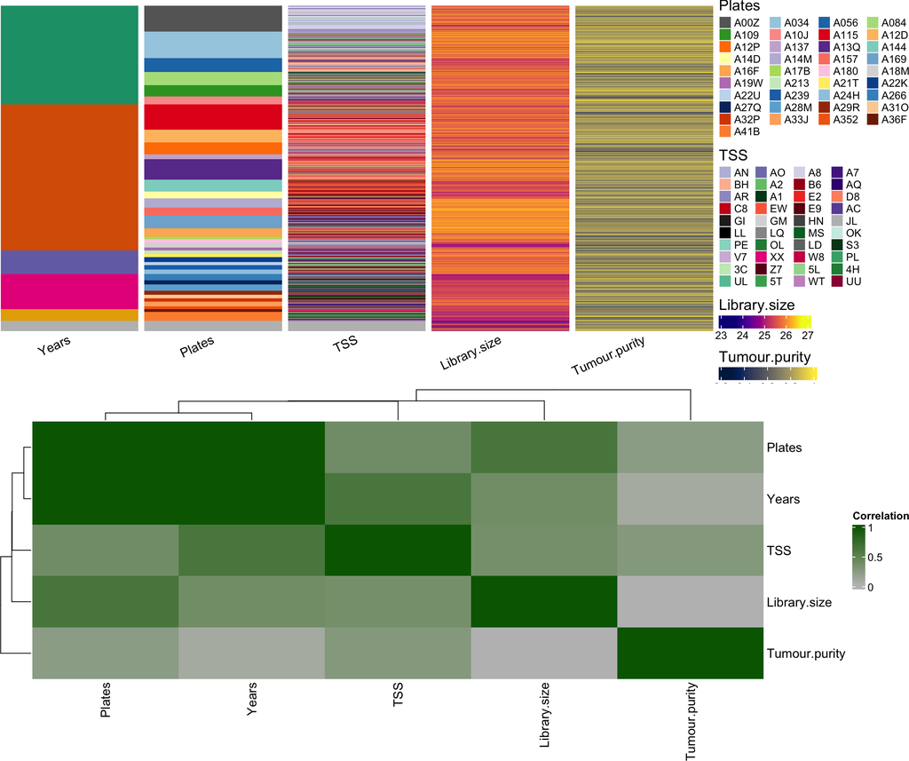

```r
# renameVariables() changes three internal colData column names to the
# labels used consistently throughout the rest of this vignette
brca.se.obj <- renameVariables(
    se.obj        = brca.se.obj,
    current.names = c('tissue_type', 'tumour.purity.estimate', 'library.size'),
    new.names     = c('Tissues', 'Tumour.purity', 'Library.size'))

# plotStudyOutline() generates:
#   - A heatmap showing the distribution of each variable across samples
#     (ordered by the batch variables applied in addTcgaBatchInfo / orderSeObj)
#   - A pairwise correlation matrix across all specified variables
brca.se.obj <- plotStudyOutline(
    se.obj      = brca.se.obj,
    plot.output = FALSE,
    variables   = c('Years', 'Plates', 'TSS', 'Library.size', 'Tumour.purity'),
    verbose     = FALSE)
grid.arrange(
  grid.grabExpr(draw(brca.se.obj@metadata$StudyOutline)),
  grid.grabExpr(draw(brca.se.obj@metadata$VariablesAssociation)),
  ncol = 1
  )
```

Plot below shows that correlation between the tumor purity estimated using the ESTIMATE and singscore methods

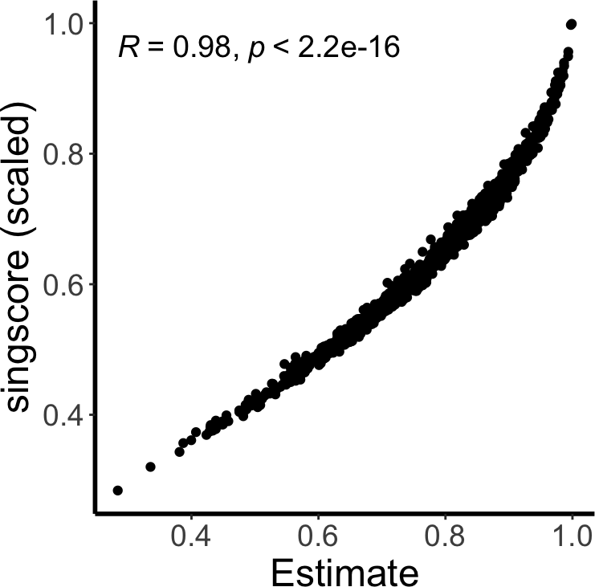

Figure 2: This scatter plot shows the correlation between tumor purity obtained using the ESTIMATE and singscore methods

```r
purity.plot <- data.frame(
    estimate  = brca.se.obj$Tumour.purity,
    singscore = brca.se.obj$tumour.purity.singscore.scaled
    )
ggplot(purity.plot, aes(x = estimate, y = singscore)) +
    geom_point() +
    xlab('Estimate') +
    ylab('singscore (scaled)') +
    stat_cor(size = 5) +
    theme(
        panel.background = element_blank(),
        axis.line        = element_line(colour = 'black', linewidth = 1),
        axis.title.x     = element_text(size = 18),
        axis.title.y     = element_text(size = 18),
        axis.text.x      = element_text(size = 14),
        axis.text.y      = element_text(size = 14))
```

Tumour purity estimates from ESTIMATE and singscore are highly correlated (Figure 2); ESTIMATE values are used for all downstream analysis.

```r
# A binary batch label is created to explicitly encode the flow cell chemistry
# change. Samples from 2010–2011 are assigned to Batch1 (older chemistry);
# samples from 2012–2014 are assigned to Batch2 (newer chemistry).
brca.se.obj$Flow.cells <- factor(
    ifelse(brca.se.obj$Years %in% c(2010, 2011), "Batch1", "Batch2"),
    levels = c("Batch1", "Batch2"))
```

# 3 Identification of Major Variation

> **Note:** This stage is unnecessary when all sources of unwanted variation and the primary gene-expression-based biological variation are already known. Only biological variables that are detectable in the expression data can be used effectively in the RUV-III normalisation procedure.

## 3.1 Step 1: Estimating PAM50 biological populations

Breast cancers are classified into five intrinsic molecular subtypes based on the PAM50 50-gene signature: **Basal**, **Her2**, **Luminal A (LumA)**, **Luminal B (LumB)**, and **Normal-like**. These subtypes are strongly associated with clinical outcomes — Basal and Her2 subtypes carry the worst prognosis, while LumA is associated with the best survival.

The TCGA publication provides PAM50 annotations in the `paper_BRCA_Subtype_PAM50` column of the `SummarizedExperiment`; these are stored as `UCF.PAM50`. Additionally, `estimatePAM50()` applies the **genefu** algorithm to estimate PAM50 subtypes *de novo* from each normalised assay.

```r
# Store the TCGA publication PAM50 annotations under a standardised name.
# "Normal" (normal-like tumour subtype) is relabelled to "Normal.like" to
# avoid confusion with normal tissue samples.
# NA entries (samples not classified in the TCGA paper) become "Not.classified"
# so they can be easily excluded from survival analysis without dropping rows.
brca.se.obj$UCF.PAM50 <- brca.se.obj$paper_BRCA_Subtype_PAM50
brca.se.obj$UCF.PAM50[brca.se.obj$UCF.PAM50 == 'Normal'] <- 'Normal.like'
brca.se.obj$UCF.PAM50[is.na(brca.se.obj$UCF.PAM50)]      <- 'Not.classified'
brca.se.obj$UCF.PAM50 <- factor(
    x      = brca.se.obj$UCF.PAM50,
    levels = c('Basal', 'Her2', 'LumA', 'LumB', 'Normal.like', 'Not.classified'))

# estimatePAM50() applies the genefu implementation for PAM50 estimates
brca.se.obj <- estimatePAM50(
    se.obj         = brca.se.obj,
    assay.names    = 'all',
    entrez.gene.id = 'entrezgene_id',
    probe          = 'gene_name',
    normalization  = NULL,
    tissue.type    = NULL,
    apply.log      = TRUE,
    verbose        = FALSE)
```

## 3.2 Step 2: Evaluating PAM50 subtype quality

Two analyses assess the quality of each assay’s PAM50 estimates:

1. **Survival association**. a well-annotated PAM50 estimate should show a significant log-rank p-value in overall survival analysis.
2. **Library size association**. an ideal PAM50 estimate should show *no* or *weak* association with library size, which is a purely technical variable.

### 3.2.1 Survival analysis

`addTcgaClinicalInfo()` integrates TCGA clinical data from Liu et al. (2018) (available as Supplementary Table 1 “mmc1.xlsx”) into the `SummarizedExperiment`. Normal tissue samples receive a value of −1 for survival time and event, enabling their automatic exclusion from survival computations. `computeSurvival()` then generates Kaplan–Meier curves for each PAM50 classification.

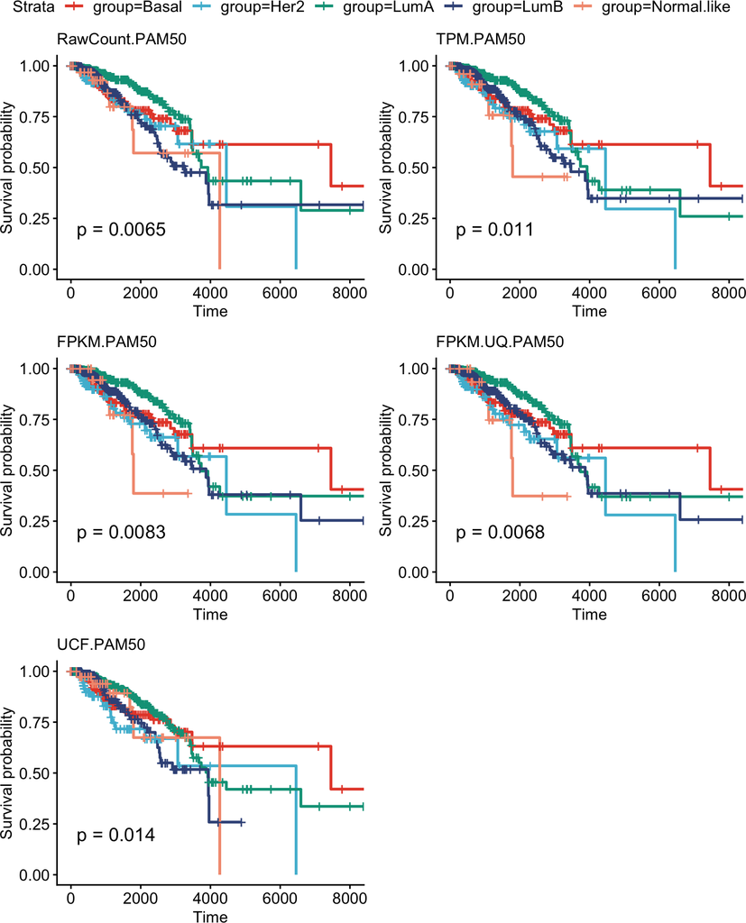

Figure 3: Kaplan-Meier plots showing the association between the estimated PAM50 subtypes and the survival outcomes of patients for different datasets

```r
# addTcgaClinicalInfo() appends the overall survival time (OS.time, in days)
# and survival event indicator (OS: 1 = deceased, 0 = censored) to colData.
# Normal tissue samples are assigned OS = -1 so that
# the idx filter below can exclude them without additional subsetting.
brca.se.obj <- addTcgaClinicalInfo(
    se.obj      = brca.se.obj,
    factors     = c("OS", "OS.time"),
    tissue.type = 'Tissues')

# Apply survival analysis to every PAM50 column simultaneously using lapply.
# grep('\\.PAM50$', ...) identifies all columns ending in ".PAM50" in colData,
# which includes both the TCGA annotation (UCF.PAM50) and the per-assay
# genefu estimates (e.g. FPKM.UQ.PAM50).
# idx excludes normal tissue samples (OS == -1) and unclassified samples
# ('Not.classified') from the Kaplan–Meier computation.
all.survivals <- lapply(
    pam50 <- grep('\\.PAM50$', colnames(colData(brca.se.obj)), value = TRUE)[c(2,3,4,5,1)],
    function(i) {
        idx <- brca.se.obj$OS != -1 & brca.se.obj[[i]] != 'Not.classified'
        computeSurvival(
            se.obj             = brca.se.obj[, idx],
            variable           = i,
            survival.time      = 'OS.time',
            survival.events    = 'OS',
            genes              = NULL,
            return.survival.plot = TRUE,
            check.se.obj       = FALSE,
            plot.output        = FALSE,
            verbose            = FALSE,
            save.se.obj        = FALSE)$plot
    })

ggarrange(
    plotlist = all.survivals,
    ncol = 2,
    nrow = 3,
    common.legend = TRUE
    )
```

### 3.2.2 Association with library size

The `plotVariables()` function produces boxplots of library size stratified by PAM50 subtype for each assay. An ideal PAM50 estimate should show *no* association with library size (a purely technical variable). Significant association suggests that the subtype estimates are confounded by technical effects.

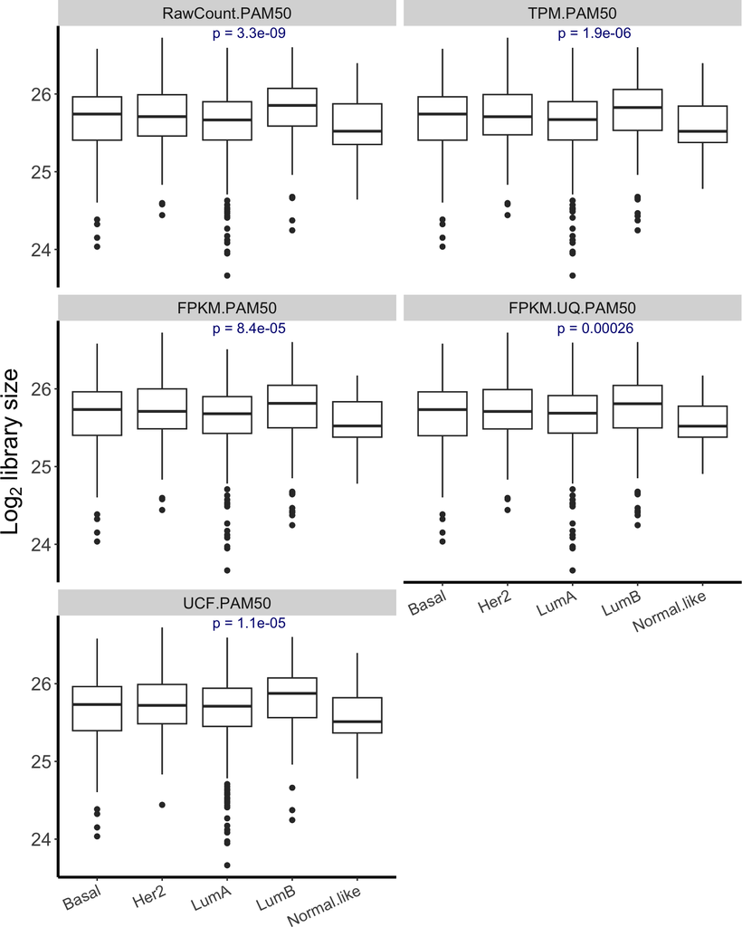

Figure 4: Shows the distribution of library size within each estimated PAM50  
One-way ANOVA was used to assess the association.

```r
# plotVariables() creates one boxplot panel per PAM50 column (x.variables),
# showing the distribution of Library.size (y.variable) within each subtype.
# generate.heatmap = TRUE also produces a summary heatmap of p-values from
# one-way ANOVA tests across all variable pairs.
# Not.classified samples are removed before plotting to focus on the five
# biologically interpretable subtypes.
to.plot <- plotVariables(
    se.obj        = brca.se.obj[, brca.se.obj$UCF.PAM50 != 'Not.classified'],
    x.variables   = grep('\\.PAM50$',
                       colnames(colData(brca.se.obj)),
                       value = TRUE)[c(2, 3, 4, 5, 1)],
    y.variables  = 'Library.size',
    y.lab        = expression(Log[2] ~ library ~ size),
    generate.heatmap = TRUE,
    nb.ncol      = 2,
    plot.out.put = FALSE)
to.plot$p.x.y
```

We save the `brca.se.obj` object for RUV-III normalization analysis.

```r
# saving the the `brca.se.obj` object
qs::qsave(x = brca.se.obj, 'TCGA_BRCA_PreProcssed.qs')
```

# 4 Summary of the analyses

The table below summarises the key objects and annotations produced during Stages 1 and 2, which are the inputs to the variation assessment (Stage 3) and normalisation (Stage 4) steps.

| Object / annotation | Description |
| --- | --- |
| `brca.se.obj` | `SummarizedExperiment` with 15,304 genes × 1,083 tumour samples |
| Assays | `RawCount`, `TPM`, `FPKM`, `FPKM.UQ` |
| `colData$Years` | Sequencing year (2010–2014), factor |
| `colData$Plates` | Sequencing plate ID |
| `colData$TSS` | Tissue Source Site code |
| `colData$Flow.cells` | Flow cell chemistry batch (Batch1 / Batch2) |
| `colData$Tumour.purity` | ESTIMATE tumour purity [0, 1] |
| `colData$Library.size` | Log₂ total counts per sample |
| `colData$UCF.PAM50` | TCGA-paper PAM50 annotations |
| `colData$FPKM.UQ.PAM50` | genefu PAM50 on FPKM.UQ (primary biological variable) |

# 5 Session Information

The out put of `sessionInfo()` can be found on the GitHub.